# rf_복습문제

6조

2020 5 14

```r
library(caret)
library(rpart)
library(randomForest)
library(rpart.plot)
```

### 주어진 데이터는 Breast Cancer Wisconsin(Diagnotic) 데이터입니다. 569개의 데이터와 32개의 속성으로 구성되어 있습니다. Target변수는 Diagnoisis 이며, B : Bengin(양성) M:Maligant(악성) 을 뜻합니다.

### 주어진 데이터를 불러오세요.

```r
wbcd<-read.csv("C://Users//a2868//Downloads//wisc_bc_data (1).csv")
wbcd<-wbcd[-1]
head(wbcd[,1:5])
```

```
##   diagnosis radius_mean texture_mean perimeter_mean area_mean
## 1         B       12.32        12.39          78.85     464.1
## 2         B       10.60        18.95          69.28     346.4
## 3         B       11.04        16.83          70.92     373.2
## 4         B       11.28        13.39          73.00     384.8
## 5         B       15.19        13.21          97.65     711.8
## 6         B       11.57        19.04          74.20     409.7
```

### createDataPartition을 사용하여 7:3으로 데이터를 traing / test set으로 분리 하세요. set.seed(1234)

```r
# 데이터 나누기
set.seed(1234)
train.idx <- createDataPartition(wbcd$diagnosis,p=0.7,list=F)
train <- wbcd[train.idx,]
test <- wbcd[-train.idx,]
```

```r
dim(train)
```

```
## [1] 399  31
```

```r
dim(test)
```

```
## [1] 170  31
```

### 1-1 Decision Tree vs RandomForst , 전 세션에서 배운 의사결정 나무와 랜덤포레스트를 비교하려 합니다. 각각 모델을 생성하고 적합하세요. set.seed(1234)

[figure not shown]

### 1-2 다음과 같이 위에서 적합한, 의사결정 나무와 랜덤포레스트를 각각 confusionmatrix을 이용하여 성능을 비교하고, 랜덤포레스트모델이 더 나은 성능을 보여주는 이유를 말해주세요.

```
## Confusion Matrix and Statistics
##
##           Reference
## Prediction   B   M
##          B 100   8
##          M   7  55
##
##                Accuracy : 0.9118
##                  95% CI : (0.8586, 0.9498)
##     No Information Rate : 0.6294
##     P-Value [Acc > NIR] : <2e-16
##
##                   Kappa : 0.8102
##
##  Mcnemar's Test P-Value : 1
##
##             Sensitivity : 0.9346
##             Specificity : 0.8730
##          Pos Pred Value : 0.9259
##          Neg Pred Value : 0.8871
##              Prevalence : 0.6294
##          Detection Rate : 0.5882
##    Detection Prevalence : 0.6353
##       Balanced Accuracy : 0.9038
##
##        'Positive' Class : B
##
```

```
## Confusion Matrix and Statistics
##
##           Reference
## Prediction   B   M
##          B 101   6
##          M   6  57
##
##                Accuracy : 0.9294
##                  95% CI : (0.8799, 0.963)
##     No Information Rate : 0.6294
##     P-Value [Acc > NIR] : <2e-16
##
##                   Kappa : 0.8487
##
##  Mcnemar's Test P-Value : 1
##
##             Sensitivity : 0.9439
##             Specificity : 0.9048
##          Pos Pred Value : 0.9439
##          Neg Pred Value : 0.9048
##              Prevalence : 0.6294
##          Detection Rate : 0.5941
##    Detection Prevalence : 0.6294
##       Balanced Accuracy : 0.9243
##
##        'Positive' Class : B
##
```

#### 랜덤포레스트에서 부스트랩 기법을 사용하는 이유는 무엇인가요?

#### 어떤 문제점을 보이고 있고,나아가 어떤 방법을 사용해 랜덤포레스트 모델은 이 문제점을 해결하나요 ?

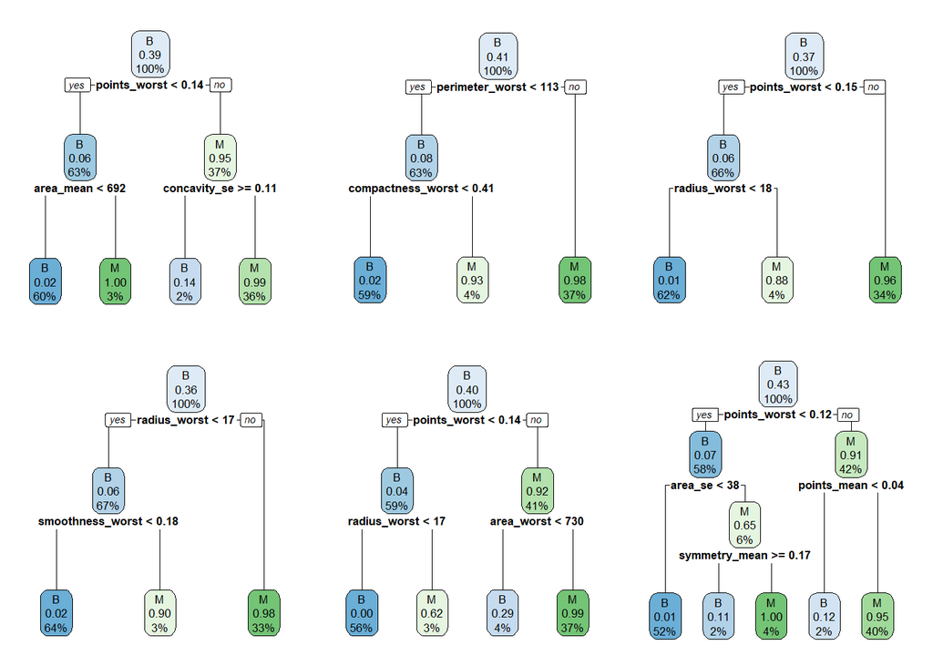

### 2-2 다음으로는 랜덤포레스트 모델의 변수중요도를 plot하세요.

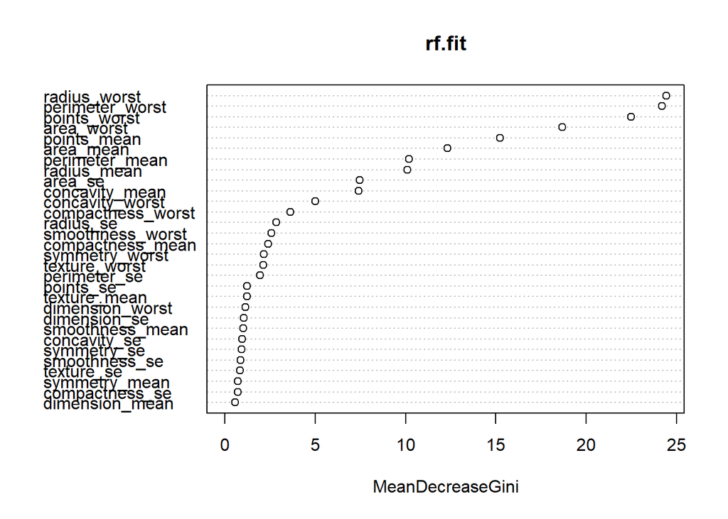

### 3-1 하이퍼 파라미터 튜닝을 해보려 합니다. 분석가는 M:Maligant(악성) 을 잘구분하는 모델을 만들고 싶어한다고 가정합니다. for 문을 이용해서 최적의 파라미터를 찾아보세요. 정답은 없습니다.

### *ntree<-c(50,75,100,150,200) mtry<-c(4,5,6,7) set.seed(1234), expand.grid(ntree=ntree,mtry=mtry) 와 for문 이용

```
## ntree= 50 mtry= 4, rf_recall :  0.9047619
## ntree= 75 mtry= 4, rf_recall :  0.9206349
## ntree= 100 mtry= 4, rf_recall :  0.9206349
## ntree= 150 mtry= 4, rf_recall :  0.9206349
## ntree= 200 mtry= 4, rf_recall :  0.9206349
## ntree= 50 mtry= 5, rf_recall :  0.9206349
## ntree= 75 mtry= 5, rf_recall :  0.9047619
## ntree= 100 mtry= 5, rf_recall :  0.9206349
## ntree= 150 mtry= 5, rf_recall :  0.8888889
## ntree= 200 mtry= 5, rf_recall :  0.9047619
## ntree= 50 mtry= 6, rf_recall :  0.9047619
## ntree= 75 mtry= 6, rf_recall :  0.9206349
## ntree= 100 mtry= 6, rf_recall :  0.9206349
## ntree= 150 mtry= 6, rf_recall :  0.9206349
## ntree= 200 mtry= 6, rf_recall :  0.9206349
## ntree= 50 mtry= 7, rf_recall :  0.9047619
## ntree= 75 mtry= 7, rf_recall :  0.9206349
## ntree= 100 mtry= 7, rf_recall :  0.9206349
## ntree= 150 mtry= 7, rf_recall :  0.9206349
## ntree= 200 mtry= 7, rf_recall :  0.9206349
```

### 3-2 찾은 파라미터를 적합하고 ConfusionMatrix로 평가해보세요.

```
## Confusion Matrix and Statistics
##
##           Reference
## Prediction   B   M
##          B 102   6
##          M   5  57
##
##                Accuracy : 0.9353
##                  95% CI : (0.8872, 0.9673)
##     No Information Rate : 0.6294
##     P-Value [Acc > NIR] : <2e-16
##
##                   Kappa : 0.8608
##
##  Mcnemar's Test P-Value : 1
##
##             Sensitivity : 0.9533
##             Specificity : 0.9048
##          Pos Pred Value : 0.9444
##          Neg Pred Value : 0.9194
##              Prevalence : 0.6294
##          Detection Rate : 0.6000
##    Detection Prevalence : 0.6353
##       Balanced Accuracy : 0.9290
##
##        'Positive' Class : B
##
```